# Eigen analysis and correlation matrix of Housing dataset

Ummul Khoirro’ Syari

2025-02-22

### Prediksi Harga Rumah Menggunakan Model Regresi

Dataset yang digunakan dalam proyek ini berasal dari penelitian yang dilakukan oleh Harrison dan Rubinfeld tahun 1978. https://www.kaggle.com/datasets/yasserh/housing-prices-dataset.

Proyek ini bertujuan untuk memprediksi harga rumah berdasarkan beberapa faktor, seperti area, bedrooms, bathrooms, guestroom, parking, dll.

Proyek ini berfokus pada pemahaman data, pemrosesan data, serta penerapan model regresi untuk mendapatkan prediksi yang akurat.

```r
# menampilkan struktur data
str(data)
```

```
## 'data.frame':    545 obs. of  13 variables:
##  $ price           : int  13300000 12250000 12250000 12215000 11410000 10850000 10150000 10150000 9870000 9800000 ...
##  $ area            : int  7420 8960 9960 7500 7420 7500 8580 16200 8100 5750 ...
##  $ bedrooms        : int  4 4 3 4 4 3 4 5 4 3 ...
##  $ bathrooms       : int  2 4 2 2 1 3 3 3 1 2 ...
##  $ stories         : int  3 4 2 2 2 1 4 2 2 4 ...
##  $ mainroad        : chr  "yes" "yes" "yes" "yes" ...
##  $ guestroom       : chr  "no" "no" "no" "no" ...
##  $ basement        : chr  "no" "no" "yes" "yes" ...
##  $ hotwaterheating : chr  "no" "no" "no" "no" ...
##  $ airconditioning : chr  "yes" "yes" "no" "yes" ...
##  $ parking         : int  2 3 2 3 2 2 2 0 2 1 ...
##  $ prefarea        : chr  "yes" "no" "yes" "yes" ...
##  $ furnishingstatus: chr  "furnished" "furnished" "semi-furnished" "furnished" ...
```

```r
# menentukan kolom numerik
numerik_data <- data[sapply(data, is.numeric)]
(numerik_data)
```

[output not shown]

[output cut: 531 more lines]

### Plot untuk setiap variabel numerik

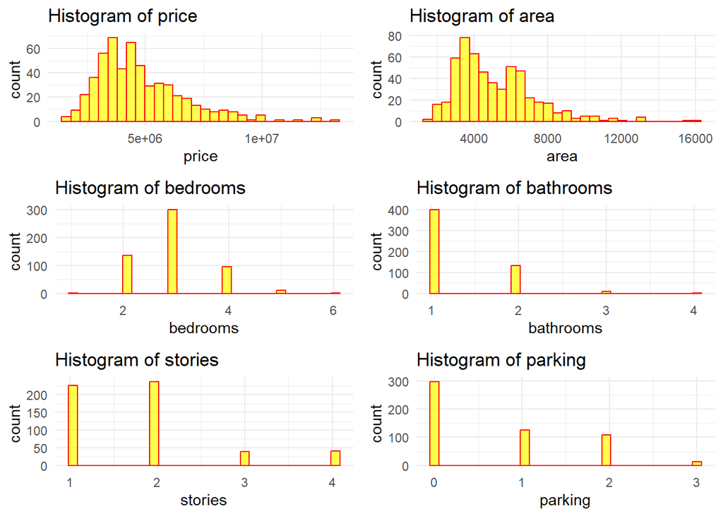

### 1. Covariant Matriks

covariant matriks menunjukkan hubungan yang linier antara variable numerik

```r
# Kovarian matriks
cov_matrix <- cov(numerik_data)
print("Covariance Matrix:")
```

```
## [1] "Covariance Matrix:"
```

```r
print(cov_matrix)
```

```
##                  price         area     bedrooms    bathrooms      stories
## price     3.498544e+12 2.175676e+09 5.059464e+05 4.864093e+05 6.826446e+05
## area      2.175676e+09 4.709512e+06 2.432321e+02 2.113466e+02 1.581294e+02
## bedrooms  5.059464e+05 2.432321e+02 5.447383e-01 1.386738e-01 2.615893e-01
## bathrooms 4.864093e+05 2.113466e+02 1.386738e-01 2.524757e-01 1.421715e-01
## stories   6.826446e+05 1.581294e+02 2.615893e-01 1.421715e-01 7.525432e-01
## parking   6.194673e+05 6.599897e+02 8.856247e-02 7.684161e-02 3.404277e-02
##                parking
## price     6.194673e+05
## area      6.599897e+02
## bedrooms  8.856247e-02
## bathrooms 7.684161e-02
## stories   3.404277e-02
## parking   7.423300e-01
```

misalkan variabel price dengan area.semakin luas area, maka akan semakin mahal price dari rumah tersebut.

### 2. Correlation Matriks

- korelasi mendekati 1 → hubungan positif yang kuat
- korelasi mendekati -1 → hubungan negatif yang kuat
- korelasi mendekati 0 → tidak ada hubungan yang signifikan

```r
# Korelasi matriks
cor_matrix <- cor(numerik_data)
print("Correlation Matrix:")
```

```
## [1] "Correlation Matrix:"
```

```r
print(cor_matrix)
```

```
##               price       area  bedrooms bathrooms    stories    parking
## price     1.0000000 0.53599735 0.3664940 0.5175453 0.42071237 0.38439365
## area      0.5359973 1.00000000 0.1518585 0.1938195 0.08399605 0.35298048
## bedrooms  0.3664940 0.15185849 1.0000000 0.3739302 0.40856424 0.13926990
## bathrooms 0.5175453 0.19381953 0.3739302 1.0000000 0.32616471 0.17749582
## stories   0.4207124 0.08399605 0.4085642 0.3261647 1.00000000 0.04554709
## parking   0.3843936 0.35298048 0.1392699 0.1774958 0.04554709 1.00000000
```

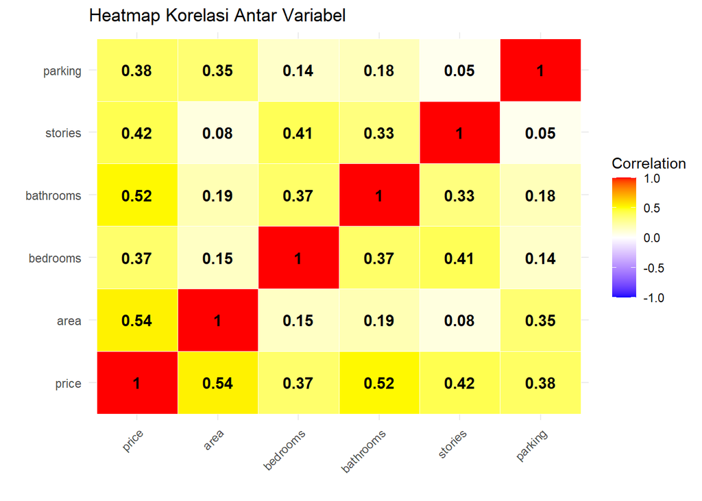

```r
# Heatmap Korelasi
library(ggplot2)
library(reshape2)

cor_melted <- melt(cor_matrix)

ggplot(data = cor_melted, aes(x = Var1, y = Var2, fill = value)) +
  geom_tile(color = "white") +
  geom_text(aes(label = round(value, 2)), size = 4, fontface = "bold") +
  scale_fill_gradientn(colors = c("blue", "white", "yellow", "red"),
                       values = scales::rescale(c(-1, 0, 0.5, 1)),
                       limits = c(-1, 1),
                       name = "Correlation") +
  theme_minimal() +
  xlab("") + ylab("") +
  theme(axis.text.x = element_text(angle = 45, hjust = 1)) +
  ggtitle("Heatmap Korelasi Antar Variabel")
```

- area → price memiliki korelasi 0.53599735, artinya luas rumah memiliki pengaruh cukup kuat terhadap harga.
- bathrooms → price memiliki korelasi 0.5175453, yang juga cukup tinggi.

### 3. Eigen value

semakin besar nilai eigen, maka akan semakin banyak informasi yang didapatkan

```r
# Menghitung Eigen value dengan Rumus |A - λI| = 0
I <- diag(ncol(cov_matrix))
lambda_values <- eigen(cov_matrix)$values

print("Eigen Values:")
```

```
## [1] "Eigen Values:"
```

```r
print(lambda_values)
```

```
## [1] 3.498546e+12 3.356500e+06 7.345801e-01 5.958731e-01 3.626262e-01
## [6] 1.677009e-01
```

3.498546e+12 merupakan nilai eigen yang paling tinggi. berarti hal tersebut memiliki informasi tertinggi tentang variabilitas data

### 4. Eigen Vektor

Eigen vektor tertinggi akan menunjukkan fitur atau faktor yang paling berkontribusi terhadap harga rumah.

```r
# Menghitung Eigen vector dengan (A - λI)v = 0
eigenvectors <- eigen(cov_matrix)$vectors

print("Eigen Vectors:")
```

```
## [1] "Eigen Vectors:"
```

```r
print(eigenvectors)
```

```
##              [,1]          [,2]          [,3]          [,4]          [,5]
## [1,] 9.999998e-01  6.218809e-04  2.350022e-07  2.360030e-07 -1.896406e-08
## [2,] 6.218809e-04 -9.999998e-01 -1.068146e-04  4.693651e-05  1.227917e-05
## [3,] 1.446162e-07  2.127405e-05 -4.831235e-01 -3.524835e-01 -7.742078e-01
## [4,] 1.390319e-07  2.715391e-05 -1.156247e-01 -7.418855e-02 -1.559105e-01
## [5,] 1.951224e-07  7.936672e-05 -7.760615e-01 -2.230034e-01  5.897316e-01
## [6,] 1.770643e-07 -8.185750e-05  3.885243e-01 -9.058261e-01  1.688515e-01
##               [,6]
## [1,]  1.167426e-07
## [2,] -2.065080e-05
## [3,]  2.072422e-01
## [4,] -9.781712e-01
## [5,]  1.465063e-02
## [6,] -4.137110e-03
```

```r
# Mengambil Eigen Value terbesar
max_eigen_index <- which.max(lambda_values)
max_eigenvectors <- eigenvectors[, max_eigen_index]

print(lambda_values[max_eigen_index])
```

```
## [1] 3.498546e+12
```

```r
print("Eigen Value Terbesar:")
```

```
## [1] "Eigen Value Terbesar:"
```

```r
print("Eigen Vector maksimal:")
```

```
## [1] "Eigen Vector maksimal:"
```

```r
print(max_eigenvectors)
```

```
## [1] 9.999998e-01 6.218809e-04 1.446162e-07 1.390319e-07 1.951224e-07
## [6] 1.770643e-07
```

- eigen value tertinggi yaitu sebesar 3.498546e+12 yang menunjukkan bahwa komponen pertama (PC1) mendominasi varians dalam data
- eigen vektor terbesar menunjukkan bahwa price memiliki bobot tertinggi sehingga menjadi faktor dominan dalam prediksi harga rumah

### 5. Regresi linear

```r
# Model regresi
model <- lm(price ~ area + bedrooms + bathrooms + stories + parking, data = numerik_data)
summary(model)
```

```
##
## Call:
## lm(formula = price ~ area + bedrooms + bathrooms + stories +
##     parking, data = numerik_data)
##
## Residuals:
##      Min       1Q   Median       3Q      Max
## -3396744  -731825   -64056   601486  5651126
##
## Coefficients:
##              Estimate Std. Error t value Pr(>|t|)
## (Intercept) -145734.5   246634.5  -0.591   0.5548
## area            331.1       26.6  12.448  < 2e-16 ***
## bedrooms     167809.8    82932.7   2.023   0.0435 *
## bathrooms   1133740.2   118828.3   9.541  < 2e-16 ***
## stories      547939.8    68894.5   7.953 1.07e-14 ***
## parking      377596.3    66804.1   5.652 2.57e-08 ***
## ---
## Signif. codes:  0 '***' 0.001 '**' 0.01 '*' 0.05 '.' 0.1 ' ' 1
##
## Residual standard error: 1244000 on 539 degrees of freedom
## Multiple R-squared:  0.5616, Adjusted R-squared:  0.5575
## F-statistic: 138.1 on 5 and 539 DF,  p-value: < 2.2e-16
```

### 6. RMSE

mengukur seberapa akurat model dalam memprediksi harga rumah.

```r
# Menghitung RMSE
predicted_prices <- predict(model, numerik_data)
actual_prices <- numerik_data$price

rmse <- sqrt(mean((predicted_prices - actual_prices)^2))
print(paste("RMSE:", rmse))
```

```
## [1] "RMSE: 1237339.30781674"
```

model saat ini memiliki RMSE sebesar 1,237,339 yang menunjukkan masih ada peluang untuk meningkatkan akurasi

### kesimpulan

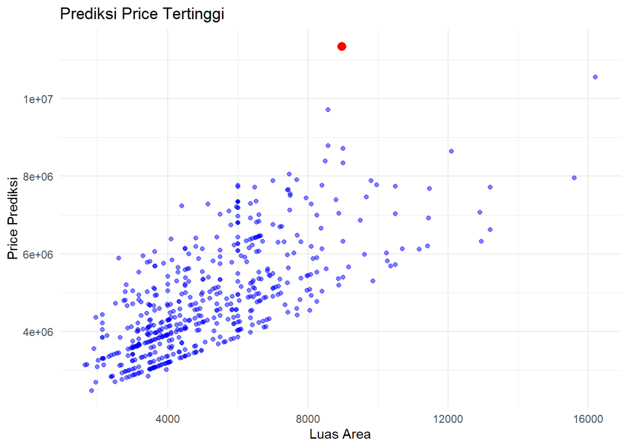

```r
# Menampilkan prediksi harga rumah tertinggi
numerik_data$predicted_price <- predicted_prices
max_price_data <- numerik_data[which.max(numerik_data$predicted_price), ]

# Visualisasi
library(ggplot2)
ggplot(numerik_data, aes(x = area, y = predicted_price)) +
  geom_point(color = "blue", alpha = 0.5) +
  geom_point(data = max_price_data, aes(x = area, y = predicted_price), color = "red", size = 3) +
  ggtitle("Prediksi Price Tertinggi") +
  xlab("Luas Area") + ylab("Price Prediksi") + theme_minimal()
```

dengan nilai RMSE sebesar 1,237,339 , model ini dapat digunakan sebagai dasar prediksi, tetapi masih dapat ditingkatkan dengan metode pemodelan yang lebih kompleks